# Lecture 7 Multi-step-ahead forecasting

$$\large{\textbf{Multi-step-ahead forecasting}}$$
$$\large{\textbf{Formalities}}$$

## One-step-ahead forecasting review

MSE-optimal forecast of $Y_{n{\color{orange}{+1}}}$ given data ${\mathscr{Y}}_{n}$ :
$$E(Y_{n{\color{orange}{+1}}} \ | \ {\mathscr{Y}}_n)$$

One-step-ahead forecast errors:  
$\qquad U_{n+1} = Y_{n+1} - E( Y_{n+1} \ | \ {\mathscr{Y}}_n )$  
satisfy  
$\qquad E(U_{n+1} \ | \ {\mathscr{Y}}_n ) = 0$  
$\Rightarrow$ errors have no autocorrelation at any lag.

## Multi-step-ahead forecasting

MSE-optimal forecast of $Y_{n{\color{magenta}{+h}}}$ given data ${\mathscr{Y}}_{n}$ :
$$E(Y_{n{\color{magenta}{+h}}} \ | \ {\mathscr{Y}}_n)$$

Multi-step-ahead forecast errors:  
$\qquad U_{\color{magenta}{{n+h \, | \, n}}} = Y_{n+h} - E( Y_{n+h} \ | \ {\mathscr{Y}}_n )$

satisfy  
$\qquad E(U_{n+h \, | \, n} \ | \ {\mathscr{Y}}_n ) = 0$

$\Rightarrow$ autocorrelation???

## Multi-step-ahead forecast errors

For any $t$: $\qquad E(U_{t+h \, | \, t} \ | \ {\mathscr{Y}}_t ) = 0$

Unconditional mean:
$$\begin{align}
{\color{cyan}{E(}} \, U_{t+h \, | \, t} \, {\color{cyan}{)}} =
{\color{cyan}{E(}} \, {\color{orange}{E(}} \, U_{t+h \, | \, t}
\ {\color{orange}{| \ {\mathscr{Y}}_t)}} \, {\color{cyan}{)}}
\qquad {\color{orange}{\text{(LIE)}}}
\end{align}$$

## Multi-step-ahead forecast errors

For any $t$: $\qquad {\color{magenta}{E(U_{t+h \, | \, t} \ | \ {\mathscr{Y}}_t ) = 0}}$

Unconditional mean:
$$\begin{align}
E(\, U_{t+h \, | \, t} \, ) &=
E(\,
{\color{magenta}{E( \, U_{t+h \, | \, t} \ | \ {\mathscr{Y}}_t)}}
\, )
\qquad \text{(LIE)} \\
&= \:\: {\color{magenta}{0}}
\end{align}$$

## Multi-step-ahead forecast errors

For any $t$: $\qquad {\color{magenta}{E(U_{t+h \, | \, t} \ | \ {\mathscr{Y}}_t ) = 0}}$

Autocovariance at lag ${\color{cyan}{j\ge h}}:$
$$\begin{align}
&\text{cov}(\, U_{t+h|t}, \, U_{t+h-j|t-j} \, )
\\
=& E(\, U_{t+h|t} \, U_{t+h-j|t-j} \, )
\quad \text{since } E(U_{t+h|t})=0 \text{ for all } t
\end{align}$$

## Multi-step-ahead forecast errors

For any $t$: $\qquad {\color{magenta}{E(U_{t+h \, | \, t} \ | \ {\mathscr{Y}}_t ) = 0}}$

Autocovariance at lag ${\color{cyan}{j\ge h}}:$
$$\begin{align}
&\text{cov}(\, U_{t+h|t}, \, U_{t+h-j|t-j} \, )
\\
=& E(\, U_{t+h|t} \, U_{t+h-j|t-j} \, )
\quad \text{since } E(U_{t+h|t})=0 \text{ for all } t
\\
=& E(\, {\color{yellow}{E(}} \, U_{t+h|t} \, U_{t+h-j|t-j} \,
{\color{yellow}{| \, {\mathscr{Y}}_t \, )}} \, )
\quad {\color{yellow}{\text{(LIE)}}}
\end{align}$$

## Multi-step-ahead forecast errors

For any $t$: $\qquad {\color{magenta}{E(U_{t+h \, | \, t} \ | \ {\mathscr{Y}}_t ) = 0}}$

Autocovariance at lag ${\color{cyan}{j\ge h}}:$
$$\begin{align}
&\text{cov}(\, U_{t+h|t}, \, U_{t+h-j|t-j} \, )
\\
=& E(\, U_{t+h|t} \, U_{t+h-j|t-j} \, )
\quad \text{since } E(U_{t+h|t})=0 \text{ for all } t
\\
=& E(\, E( \, U_{t+h|t} \, U_{t+h-j|t-j} \, | \, {\mathscr{Y}}_t \, ) \, )
\quad \text{(LIE)}
\\
=& E(\, {\color{cyan}{U_{t+h-j|t-j}}} \, E( \, U_{t+h|t} \, | \, {\mathscr{Y}}_t \, ) \, )
\quad {\color{cyan}{\text{since } t+h-j \le t}}
\end{align}$$

## Multi-step-ahead forecast errors

For any $t$: $\qquad {\color{magenta}{E(U_{t+h \, | \, t} \ | \ {\mathscr{Y}}_t ) = 0}}$

Autocovariance at lag ${\color{cyan}{j\ge h}}:$
$$\begin{align}
&\text{cov}(\, U_{t+h|t}, \, U_{t+h-j|t-j} \, )
\\
=& E(\, U_{t+h|t} \, U_{t+h-j|t-j} \, )
\quad \text{since } E(U_{t+h|t})=0 \text{ for all } t
\\
=& E(\, E( \, U_{t+h|t} \, U_{t+h-j|t-j} \, | \, {\mathscr{Y}}_t \, ) \, )
\quad \text{(LIE)}
\\
=& E(\, U_{t+h-j|t-j} \,
{\color{magenta}{E( \, U_{t+h|t} \, | \, {\mathscr{Y}}_t \, )}} \, )
\quad \text{since } t+h-j \le t
\\
=& \: {\color{magenta}{0}}
\end{align}$$

## Multi-step-ahead forecast errors

For any $t$: $\qquad {\color{magenta}{E(U_{t+h \, | \, t} \ | \ {\mathscr{Y}}_t ) = 0}}$

Autocovariance at lag ${\color{red}{j<h}}:$
$$\begin{align}
&\text{cov}(\, U_{t+h|t}, \, U_{t+h-j|t-j} \, )
\\
=& E(\, U_{t+h|t} \, U_{t+h-j|t-j} \, )
\quad \text{since } E(U_{t+h|t})=0 \text{ for all } t
\\
=& E(\, E( \, U_{t+h|t} \, U_{t+h-j|t-j} \, | \, {\mathscr{Y}}_t \, ) \, )
\quad \text{(LIE)}
\\
{\color{red}{\large\ne}}& E(\, {\color{red}{U_{t+h-j|t-j}}} \, E( \, U_{t+h|t} \, | \, {\mathscr{Y}}_t \, ) \, )
\quad {\color{red}{\text{since } t+h-j > t}}
\end{align}$$

## Multi-step-ahead forecast errors

For any $t$: $\qquad E(U_{t+h \, | \, t} \ | \ {\mathscr{Y}}_t ) = 0$

$$\text{cov}(\, U_{t+h|t}, \, U_{t+h-j|t-j} \, ) =
\begin{cases}
? & j=1,\ldots,h-1 \\
0 & j=h,h+1,\ldots
\end{cases}$$

## Multi-step-ahead forecast errors

For any $t$: $\qquad E(U_{t+h \, | \, t} \ | \ {\mathscr{Y}}_t ) = 0$

$$\text{cov}(\, U_{t{\color{magenta}{+h}}|t}, \, U_{t{\color{magenta}{+h}}-j|t-j} \, ) =
\begin{cases}
\textbf{?} & j=1,\ldots,h-1 \\
{\color{orange}{0}} & {\color{cyan}{j=h,h+1,\ldots}}
\end{cases}$$

*h*-step-ahead forecast errors have zero autocorrelation at lags ${\color{cyan}{h,\, h+1, \, \ldots}}$.

## Multi-step-ahead forecast errors

For any $t$: $\qquad E(U_{t+h \, | \, t} \ | \ {\mathscr{Y}}_t ) = 0$

$$\text{cov}(\, U_{t{\color{magenta}{+h}}|t}, \, U_{t{\color{magenta}{+h}}-j|t-j} \, ) =
\begin{cases}
{\color{orange}{\textbf{?}}} & {\color{cyan}{j=1,\ldots,h-1}} \\
0 & j=h,h+1,\ldots
\end{cases}$$

*h*-step-ahead forecast errors *may* have non-zero autocorrelation at lags ${\color{cyan}{1,\ldots, h-1}}$.

$$\large{\textbf{Multi-step-ahead forecasting}}$$
$$\large{\textbf{Approach 1}}$$

## Multi-step forecasts from 1-step models

The most common approach:

- specify model of $E(\, Y_t \, | \, {\mathscr{Y}}_{t-1} \, )$, eg ARIMA
- use “extended” LIE ${\color{lime}{E(}} \, Y \, {\color{lime}{| \, {\mathscr{F}} \,)}} = {\color{lime}{E(}} \, {\color{orange}{E(}} \, Y \, {\color{orange}{| \, {\mathscr{G}})}} \, {\color{lime}{| \, {\mathscr{F}} \, )}} \:\: \quad \text{if } {\color{lime}{{\mathscr{F}}}} \subset {\color{orange}{{\mathscr{G}}}}$

## Multi-step forecasts from 1-step models

The most common approach:

- specify model of $E(\, Y_t \, | \, {\mathscr{Y}}_{t-1} \, )$, eg ARIMA
- use “extended” LIE ${\color{lime}{E(}} \, Y \, {\color{lime}{| \, {\mathscr{F}} \,)}} = {\color{lime}{E(}} \, {\color{orange}{E(}} \, Y \, {\color{orange}{| \, {\mathscr{G}})}} \, {\color{lime}{| \, {\mathscr{F}} \, )}} \:\: \quad \text{if } {\color{lime}{{\mathscr{F}}}} \subset {\color{orange}{{\mathscr{G}}}}$  
  to *derive* multi-step-ahead forecasts. Eg: ${\color{lime}{E(}} \, Y_{n+2} \, {\color{lime}{| \, {\mathscr{Y}}_{n} \,)}} = {\color{lime}{E(}} \, {\color{orange}{E(}} \, Y_{n+2} \, {\color{orange}{| \, {\mathscr{Y}}_{n+1})}} \, {\color{lime}{| \, {\mathscr{Y}}_n \, )}} \qquad\quad\:\:$  
  $\qquad\qquad\qquad\qquad\qquad\qquad\text{since } {\color{lime}{{\mathscr{Y}}_{n}}} \subset {\color{orange}{{\mathscr{Y}}_{n+1}}}$

## Multi-step forecasts from 1-step models

The most common approach:

- specify model of $E(\, Y_t \, | \, {\mathscr{Y}}_{t-1} \, )$, eg ARIMA
- use “extended” LIE ${\color{white}{E(}} \, Y \, {\color{white}{| \, {\mathscr{F}} \,)}} = {\color{white}{E(}} \, {\color{white}{E(}} \, Y \, {\color{white}{| \, {\mathscr{G}})}} \, {\color{white}{| \, {\mathscr{F}} \, )}} \:\: \quad \text{if } {\color{white}{{\mathscr{F}}}} \subset {\color{white}{{\mathscr{G}}}}$  
  to *derive* multi-step-ahead forecasts. Eg: ${\color{white}{E(}} \, Y_{n+2} \, {\color{white}{| \, {\mathscr{Y}}_{n} \,)}} = {\color{white}{E(}} \, {\color{white}{E(}} \, Y_{n+2} \, {\color{white}{| \, {\mathscr{Y}}_{n+1})}} \, {\color{white}{| \, {\mathscr{Y}}_n \, )}} \qquad\quad\:\:$  
  $\qquad\qquad\qquad\qquad\qquad\qquad\text{since } {\color{magenta}{{\mathscr{Y}}_{n}\subset {\mathscr{Y}}_{n+1}}}$  
  $\qquad\qquad\qquad\qquad\qquad\qquad\qquad\qquad{\color{magenta}{\uparrow}}$  
  More data at time ${\color{magenta}{n+1}}$ than time ${\color{magenta}{n}}$.

## Multi-step forecasts from 1-step models

The most common approach:

- specify model of ${\color{cyan}{E(\, Y_t \, | \, {\mathscr{Y}}_{t-1} \, )}}$, eg ARIMA
- use “extended” LIE ${\color{white}{E(}} \, Y \, {\color{white}{| \, {\mathscr{F}} \,)}} = {\color{white}{E(}} \, {\color{white}{E(}} \, Y \, {\color{white}{| \, {\mathscr{G}})}} \, {\color{white}{| \, {\mathscr{F}} \, )}} \:\: \quad \text{if } {\color{white}{{\mathscr{F}}}} \subset {\color{white}{{\mathscr{G}}}}$  
  to *derive* multi-step-ahead forecasts. Eg: ${\color{white}{E(}} \, Y_{n+2} \, {\color{white}{| \, {\mathscr{Y}}_{n} \,)}} = {\color{white}{E(}} \, {\color{cyan}{E( \, Y_{n+2} \, | \, {\mathscr{Y}}_{n+1})}} \, {\color{white}{| \, {\mathscr{Y}}_n \, )}} \qquad\quad\:\:$  
  $\qquad\qquad\qquad\qquad\qquad\quad{\color{cyan}{\uparrow}}$  
  $\qquad\qquad\qquad\qquad$1-step-ahead forecast

## Example. AR(1) model

$$E(\, Y_{n+1} \, | \, {\mathscr{Y}}_n \, ) = \phi_1 Y_{n}$$

2-step-ahead forecast:
$$E(\, Y_{n+2} \, | \, {\mathscr{Y}}_n \, )
=
E(\, E(\, Y_{n+2} \, | \, {\mathscr{Y}}_{n+1} \,) \, | \, {\mathscr{Y}}_n \, )$$

## Example. AR(1) model

$${\color{cyan}{E(\, Y_{n+1} \, | \, {\mathscr{Y}}_n \, ) = \phi_1 Y_{n}}}$$

2-step-ahead forecast:
$$\begin{align}
E(\, Y_{n+2} \, | \, {\mathscr{Y}}_n \, )
&=
E(\, {\color{cyan}{E(\, Y_{n+2} \, | \, {\mathscr{Y}}_{n+1} \,)}} \, | \, {\mathscr{Y}}_n \, )
\\
&=
E(\qquad {\color{cyan}{\phi_1 Y_{n+1}}} \quad\:\:\:\: | \, {\mathscr{Y}}_n \, ) \\
& \phantom{=}
\end{align}$$

## Example. AR(1) model

$$E(\, Y_{n+1} \, | \, {\mathscr{Y}}_n \, ) = \phi_1 Y_{n}$$

2-step-ahead forecast:
$$\begin{align}
E(\, Y_{n+2} \, | \, {\mathscr{Y}}_n \, )
&=
E(\, E(\, Y_{n+2} \, | \, {\mathscr{Y}}_{n+1} \,) \, | \, {\mathscr{Y}}_n \, )
\\
&=
{\color{lime}{E(}} \qquad {\color{magenta}{\phi_1}}
{\color{lime}{Y_{n+1} \quad\:\:\:\: | \, {\mathscr{Y}}_n \, )}} \\
&= {\color{magenta}{\phi_1}} \:
{\color{lime}{E( \quad Y_{n+1} \quad | \: {\mathscr{Y}}_n \, )}}
\end{align}$$

## Example. AR(1) model

$${\color{cyan}{E(\, Y_{n+1} \, | \, {\mathscr{Y}}_n \, ) = \phi_1 Y_{n}}}$$

2-step-ahead forecast:
$$\begin{align}
E(\, Y_{n+2} \, | \, {\mathscr{Y}}_n \, )
&=
E(\, E(\, Y_{n+2} \, | \, {\mathscr{Y}}_{n+1} \,) \, | \, {\mathscr{Y}}_n \, )
\\
&=
E( \qquad \phi_1
Y_{n+1} \quad\:\:\:\: | \, {\mathscr{Y}}_n \, ) \\
&= \phi_1 \:
{\color{cyan}{E( \quad Y_{n+1} \quad | \: {\mathscr{Y}}_n \, )}}
\\
&= \phi_1 \quad {\color{cyan}{\phi_1 Y_n}}
\end{align}$$

## Example. AR(1) model

$$E(\, Y_{n+1} \, | \, {\mathscr{Y}}_n \, ) = \phi_1 Y_{n}$$

2-step-ahead forecast:
$$\begin{align}
E(\, Y_{n{\color{yellow}{+2}}} \, | \, {\mathscr{Y}}_n \, )
&=
E(\, E(\, Y_{n+2} \, | \, {\mathscr{Y}}_{n+1} \,) \, | \, {\mathscr{Y}}_n \, )
\\
&=
E( \qquad \phi_1
Y_{n+1} \quad\:\:\:\: | \, {\mathscr{Y}}_n \, ) \\
&= \phi_1 \:
E( \quad Y_{n+1} \quad | \: {\mathscr{Y}}_n \, )
\\
&= \phi_1 \quad \phi_1 Y_n \\
&= \phi_1^{\color{yellow}{2}} Y_n
\end{align}$$

## Example. AR(1) model

$$\begin{align}
&E(\, Y_{n+1} \, | \, {\mathscr{Y}}_n \, ) = \phi_1 Y_{n} \\
&E(\, Y_{n+2} \, | \, {\mathscr{Y}}_n \, ) = \phi_1^2 Y_{n}
\end{align}$$

3-step-ahead forecast:
$$\begin{align}
{\color{yellow}{E(\, }}
Y_{n+3} \,
{\color{yellow}{| \, {\mathscr{Y}}_n \, )}}
&=
{\color{yellow}{E(\, }}
{\color{magenta}{E(\,}}
Y_{n+3} \:
{\color{magenta}{| \, {\mathscr{Y}}_{n+1} \,) \, }}
{\color{yellow}{| \, {\mathscr{Y}}_n \, )}}
\end{align}$$

## Example. AR(1) model

$$\begin{align}
&E(\, Y_{n+1} \, | \, {\mathscr{Y}}_n \, ) = \phi_1 Y_{n} \\
&{\color{cyan}{E(\, Y_{n+2} \, | \, {\mathscr{Y}}_n \, ) = \phi_1^2 Y_{n}}}
\end{align}$$

3-step-ahead forecast:
$$\begin{align}
E(\,
Y_{n+3} \,
| \, {\mathscr{Y}}_n \, )
&=
E(\,
{\color{cyan}{E(\,
Y_{n+3} \:
| \, {\mathscr{Y}}_{n+1} \,)}} \,
| \, {\mathscr{Y}}_n \, )
\\
&=
E(\,
\qquad{\color{cyan}{\phi_1^2 Y_{n+1}}}\quad\:\:
| \, {\mathscr{Y}}_n \, )
\end{align}$$

## Example. AR(1) model

$$\begin{align}
&E(\, Y_{n+1} \, | \, {\mathscr{Y}}_n \, ) = \phi_1 Y_{n} \\
&E(\, Y_{n+2} \, | \, {\mathscr{Y}}_n \, ) = \phi_1^2 Y_{n}
\end{align}$$

3-step-ahead forecast:
$$\begin{align}
E(\,
Y_{n+3} \,
| \, {\mathscr{Y}}_n \, )
&=
E(\,
E(\,
Y_{n+3} \:
| \, {\mathscr{Y}}_{n+1} \,) \,
| \, {\mathscr{Y}}_n \, )
\\
&=
{\color{lime}{E(}}\,
\qquad{\color{orange}{\phi_1^2}} {\color{lime}{Y_{n+1}\quad\:\:
| \, {\mathscr{Y}}_n \, )}}
\\
&=
{\color{orange}{\phi_1^2}} \:\:
{\color{lime}{E(\,
\:\:\: Y_{n+1}\quad\:\:
| \: {\mathscr{Y}}_n \, )}}
\end{align}$$

## Example. AR(1) model

$$\begin{align}
&{\color{lime}{E(\, Y_{n+1} \, | \, {\mathscr{Y}}_n \, ) = \phi_1 Y_{n}}} \\
&E(\, Y_{n+2} \, | \, {\mathscr{Y}}_n \, ) = \phi_1^2 Y_{n}
\end{align}$$

3-step-ahead forecast:
$$\begin{align}
E(\,
Y_{n+3} \,
| \, {\mathscr{Y}}_n \, )
&=
E(\,
E(\,
Y_{n+3} \:
| \, {\mathscr{Y}}_{n+1} \,) \,
| \, {\mathscr{Y}}_n \, )
\\
&=
E(\,
\qquad\phi_1^2 Y_{n+1}\quad\:\:
| \, {\mathscr{Y}}_n \, )
\\
&=
\phi_1^2 \:\:
{\color{lime}{E(\,
\:\:\: Y_{n+1}\quad\:\:
| \: {\mathscr{Y}}_n \, )}}
\\
&= \phi_1^2 \quad {\color{lime}{\phi_1 Y_n}}
\end{align}$$

## Example. AR(1) model

$$\begin{align}
&E(\, Y_{n+1} \, | \, {\mathscr{Y}}_n \, ) = \phi_1 Y_{n} \\
&E(\, Y_{n+2} \, | \, {\mathscr{Y}}_n \, ) = \phi_1^2 Y_{n}
\end{align}$$

3-step-ahead forecast:
$$\begin{align}
E(\,
Y_{n{\color{yellow}{+3}}} \,
| \, {\mathscr{Y}}_n \, )
&=
E(\,
E(\,
Y_{n+3} \:
| \, {\mathscr{Y}}_{n+1} \,) \,
| \, {\mathscr{Y}}_n \, )
\\
&=
E(\,
\qquad\phi_1^2 Y_{n+1}\quad\:\:
| \, {\mathscr{Y}}_n \, )
\\
&=
\phi_1^2 \:\:
E(\,
\:\:\: Y_{n+1}\quad\:\:
| \: {\mathscr{Y}}_n \, )
\\
&= \phi_1^{\color{yellow}{3}} \:\: Y_n
\end{align}$$

## Example. AR(1) model

For any $h=1,2,\ldots$
$$\begin{align}
E(\, Y_{n+h} \, | \, {\mathscr{Y}}_n \, ) = \phi_1^h \: Y_{n}
\end{align}$$

This process can be applied to derive the *h*-step-ahead forecasting formulae for any ARIMA model.

(But R `forecast` handles these formulae for us!)

$$\large{\textbf{Short- vs long-term forecasting}}$$

## What happens as *h* increases?

Consider the AR(1) model  
$\qquad E( \, Y_t \, | \, {\mathscr{Y}}_{t-1} \, ) = \phi_1 Y_{t-1}$  
with $h$-step-ahead forecast function $\qquad E( \, Y_{n+h} \, | \, {\mathscr{Y}}_{n} \, ) = \phi_1^h Y_{n}$

## What happens as *h* increases?

Consider the AR(1) model  
$\qquad E( \, Y_t \, | \, {\mathscr{Y}}_{t-1} \, ) = \phi_1 Y_{t-1}$  
with ${\color{magenta}{h}}$-step-ahead forecast function $\qquad E( \, Y_{n{\color{magenta}{+h}}} \, | \, {\mathscr{Y}}_{n} \, ) = \phi_1^{\color{magenta}{h}} Y_{n}$

As ${\color{magenta}{h \rightarrow \infty}}$:

- $|\phi_1|<1$ $\quad\Rightarrow\quad$ $\phi_1^{\color{magenta}{h}} \rightarrow 0$
- $\phantom{|}\phi_1\phantom{|}=1$ $\quad\Rightarrow\quad$ $\phi_1^{\color{magenta}{h}}=1$ for every ${\color{magenta}{h}}$
- $|\phi_1|>1$ $\quad\Rightarrow\quad$ $\phi_1^{\color{magenta}{h}} \rightarrow \infty$

## What happens as *h* increases?

Consider the AR(1) model  
$\qquad E( \, Y_t \, | \, {\mathscr{Y}}_{t-1} \, ) = \phi_1 Y_{t-1}$  
with ${\color{lime}{h}}$-step-ahead forecast function $\qquad {\color{lime}{E( \, Y_{n+h} \, | \, {\mathscr{Y}}_{n} \, )}} = \phi_1^h Y_{n}$

As $h \rightarrow \infty$:

- $|\phi_1|<1$ $\quad\Rightarrow\quad$ ${\color{lime}{E( \, Y_{n+h} \, | \, {\mathscr{Y}}_{n} \, )}} \rightarrow 0$
- $\phantom{|}\phi_1\phantom{|}=1$ $\quad\Rightarrow\quad$ ${\color{lime}{E( \, Y_{n+h} \, | \, {\mathscr{Y}}_{n} \, )}} = Y_n$ for every $h$
- $|\phi_1|>1$ $\quad\Rightarrow\quad$ ${\color{lime}{E( \, Y_{n+h} \, | \, {\mathscr{Y}}_{n} \, )}} \rightarrow \pm\infty$

## Numerical illustration with $Y_n = 2$

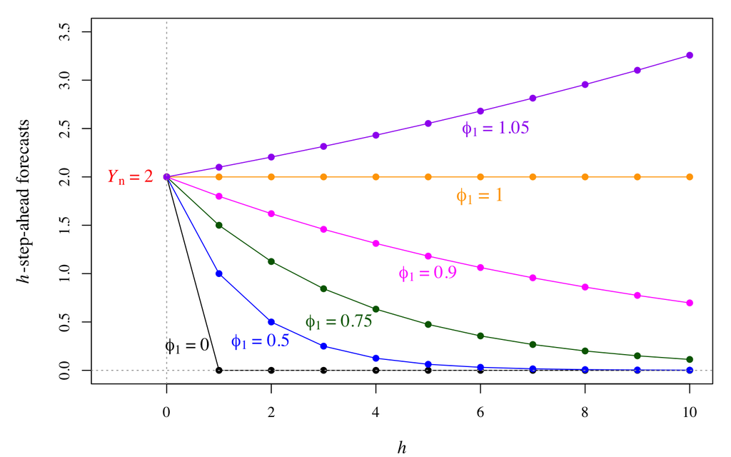

## Forecasting with a trend function

Suppose $X_t$ specifies a *deterministic* trend:  
$\qquad\quad Y_t = X_t'\beta + Z_t$  
$\qquad E(\, Z_t \, | \, {\mathscr{Z}}_{t-1} \, ) = \phi_1 Z_{t-1}$

## Forecasting with a trend function

Suppose $X_t$ specifies a *deterministic* trend:  
$\qquad\quad Y_t = X_t'\beta + Z_t$  
$\qquad E(\, Z_t \, | \, {\mathscr{Z}}_{t-1} \, ) = \phi_1 Z_{t-1}$

Then
$$\begin{align}
E(\, Y_{n+h} \, &| \, {\mathscr{Y}}_{n} \, )
= {\color{orange}{X_{n+h}'}}\beta + E(\, Z_{n+h} \, | \, {\mathscr{Y}}_{n} \, )
\\
& \qquad\qquad\uparrow \\
& \text{Future values of } {\color{orange}{X_t}} \text{ are }
{\color{cyan}{\textit{known.}}} \\
& \text{i.e. no need to forecast these} \\
\end{align}$$

## Forecasting with a trend function

Suppose $X_t$ specifies a *deterministic* trend:  
$\qquad\quad Y_t = X_t'\beta + Z_t$  
$\qquad E(\, Z_t \, | \, {\mathscr{Z}}_{t-1} \, ) = \phi_1 Z_{t-1}$

Then
$$\begin{align}
E(\, Y_{n+h} \, | \, {\mathscr{Y}}_{n} \, )
&= X_{n+h}'\beta + E(\, Z_{n+h} \, | \, {\color{lime}{{\mathscr{Y}}_{n}}} \, ) \\
&= X_{n+h}'\beta + E(\, Z_{n+h} \, | \, {\color{lime}{{\mathscr{Z}}_{n}}} \, )
\end{align}$$

$X_t$ is deterministic $\Rightarrow$ ${\color{lime}{{\mathscr{Y}}_{n}}}$ and ${\color{lime}{{\mathscr{Z}}_{n}}}$ are equivalent.

## Forecasting with a trend function

Suppose $X_t$ specifies a *deterministic* trend:  
$\qquad\quad Y_t = X_t'\beta + Z_t$  
$\qquad {\color{magenta}{E(\, Z_t \, | \, {\mathscr{Z}}_{t-1} \, ) = \phi_1 Z_{t-1}}}$

Then
$$\begin{align}
E(\, Y_{n+h} \, | \, {\mathscr{Y}}_{n} \, )
&= X_{n+h}'\beta + E(\, Z_{n+h} \, | \, {\mathscr{Y}}_{n} \, ) \\
&= X_{n+h}'\beta + {\color{magenta}{E(\, Z_{n+h} \, | \, {\mathscr{Z}}_{n} \, )}} \\
&= X_{n+h}'\beta + \quad {\color{magenta}{\phi_1^h \, Z_n}}
\end{align}$$

## Forecasting with a trend function

Suppose $X_t$ specifies a *deterministic* trend:  
$\qquad\quad {\color{yellow}{Y_t = X_t'\beta + Z_t}}$  
$\qquad E(\, Z_t \, | \, {\mathscr{Z}}_{t-1} \, ) = \phi_1 Z_{t-1}$

Then
$$\begin{align}
\:\:\, E(\, Y_{n+h} \, | \, {\mathscr{Y}}_{n} \, )
&= X_{n+h}'\beta + E(\, Z_{n+h} \, | \, {\mathscr{Y}}_{n} \, ) \\
&= X_{n+h}'\beta + E(\, Z_{n+h} \, | \, {\mathscr{Z}}_{n} \, ) \\
&= X_{n+h}'\beta + \quad \phi_1^h \, {\color{yellow}{Z_n}} \\
&= X_{n+h}'\beta + \: \phi_1^h \, {\color{yellow}{(Y_n-X_n'\beta)}}
\end{align}$$

## Forecasting with a trend function

Suppose $X_t$ specifies a *deterministic* trend:  
$\qquad\quad Y_t = {\color{cyan}{X_t'\beta}} + Z_t$  
$\qquad {\color{yellow}{E(\, Z_t \, | \, {\mathscr{Z}}_{t-1} \, ) = \phi_1 Z_{t-1}}}$

Then
$$\begin{align}
\:\:\, {\color{orange}{E(\, Y_{n+h} \, | \, {\mathscr{Y}}_{n} \, )}}
&=
{\color{cyan}{X_{n+h}'\beta}} + \:
{\color{yellow}{\phi_1^h \, (Y_n-X_n'\beta)}} \\
{\color{orange}{\text{forecast for }}} \: & \quad\:
{\color{cyan}{\text{trend at}}} \quad\quad
{\color{yellow}{\text{forecast for}}}
\\
{\color{orange}{\text{time } n+h \:\:}} & \:\:\:
{\color{cyan}{\text{time } n+h}} \quad
{\color{yellow}{\text{deviation from}}} \\
& \qquad\qquad\quad\:\:\:
{\color{yellow}{\text{trend at time } n+h}}
\end{align}$$

## Forecasting with a trend function

$$\begin{align}
\:\:\, {\color{lime}{E(\, Y_{n+h} \, | \, {\mathscr{Y}}_{n} \, )}}
&= {\color{magenta}{X_{n+h}'\beta}} + \: {\color{cyan}{\phi_1^h}} \, (Y_n-X_n'\beta)
\end{align}$$

As $h \rightarrow \infty$:

$\quad {\color{cyan}{|\phi_1|<1}}$ $\quad\Rightarrow\quad$ ${\color{lime}{E( \, Y_{n+h} \, | \, {\mathscr{Y}}_{n} \, )}} - {\color{magenta}{X_{n+h}'\beta}} \rightarrow {\color{cyan}{0}}$

Stationarity implies the forecasts converge to the trend function as the forecast horizon $h$ increases.

## Forecasting with a trend function

$$\begin{align}
\:\:\, {\color{lime}{E(\, Y_{n+h} \, | \, {\mathscr{Y}}_{n} \, )}}
&= {\color{magenta}{X_{n+h}'\beta}} + \: {\color{cyan}{\phi_1^h}} \, (Y_n-X_n'\beta)
\end{align}$$

As $h \rightarrow \infty$:

$\:\: {\color{cyan}{\phi_1=1}}$ $\:\: \Rightarrow\:\:$ ${\color{lime}{E( \, Y_{n+h} \, | \, {\mathscr{Y}}_{n} \, )}} - {\color{magenta}{X_{n+h}'\beta}} = Y_n-X_n'\beta$

A unit root implies the time series is **not** forecast to return to its trend, regardless of length of time horizon.

## Forecasting with a trend function

$$\begin{align}
\:\:\, {\color{lime}{E(\, Y_{n+h} \, | \, {\mathscr{Y}}_{n} \, )}}
&= {\color{magenta}{X_{n+h}'\beta}} + \: {\color{cyan}{\phi_1^h}} \, (Y_n-X_n'\beta)
\end{align}$$

As $h \rightarrow \infty$:

$\quad {\color{cyan}{|\phi_1|>1}}$ $\quad\Rightarrow\quad$ ${\color{lime}{E( \, Y_{n+h} \, | \, {\mathscr{Y}}_{n} \, )}} - {\color{magenta}{X_{n+h}'\beta}} \rightarrow {\color{cyan}{\pm\infty}}$

An explosive AR model implies the forecasts diverge from the trend function as the forecast horizon $h$ increases.

## Forecasting with a trend function + ARMA

$$\begin{align}
Y_t &= X_t'\beta + Z_t \\
Z_t &= \phi_1 Z_{t-1} + \ldots + \phi_p Z_{t-p} \\
& \qquad + U_t + \theta_1 U_{t-1} + \ldots + \theta_q U_{t-q}
\end{align}$$

- $Z_t$ stationary $\:\Rightarrow\:$ $\:\:$ as $h\rightarrow\infty:$  
  $\quad E( \, Y_{t+h} \, | \, {\mathscr{Y}}_n \, ) - X_{n+h}'\beta \rightarrow 0$
- $Y_t$ is called “*trend stationary*” or  
  “*mean reverting*” or “*mixingale*”.

## Forecasting with a trend function + ARMA

$$\begin{align}
Y_t &= X_t'\beta + Z_t \\
Z_t &= \phi_1 Z_{t-1} + \ldots + \phi_p Z_{t-p} \\
& \qquad + U_t + \theta_1 U_{t-1} + \ldots + \theta_q U_{t-q}
\end{align}$$

- $Z_t$ unit root $\:\:\: \Rightarrow\:$ $\:\:$ as $h\rightarrow\infty:$  
  $\quad E( \, Y_{t+h} \, | \, {\mathscr{Y}}_n \, ) - X_{n+h}'\beta \rightarrow Y_n-X_n'\beta$
- $Z_t$ is called “*difference stationary*”.

$$\large{\textbf{Multi-step-ahead forecasting}}$$
$$\large{\textbf{Approach 2}}$$

## Direct forecasting

Usual approach:

- model $E(Y_{n+1}|{\mathscr{F}}_n)$
- then derive $E(Y_{n+h}|{\mathscr{F}}_n)$ for $h=1,2,\ldots$

“Direct forecasting”:

- model $E(Y_{n+h}|{\mathscr{F}}_n)$ for $h=1,2,\ldots$

## Direct forecasting with AR models

$$\begin{align}
E( \, Y_{t} \, | \, {\mathscr{Y}}_{t-1} \, ) &=
\phi_{1}^{(1)} Y_{t-1} + \phi_{2}^{(1)} Y_{t-2} + \ldots
\\
E( \, Y_{t} \, | \, {\mathscr{Y}}_{t-2} \, ) &=
\quad
\phi_{2}^{(2)} Y_{t-2} + \phi_{3}^{(2)} Y_{t-3} + \ldots
\\
E( \, Y_{t} \, | \, {\mathscr{Y}}_{t-3} \, ) &=
\quad\quad
\phi_{3}^{(3)} Y_{t-3} + \phi_{4}^{(3)} Y_{t-4} + \ldots
\\
\qquad\qquad \vdots
\end{align}$$

i.e. specify and estimate a *separate* model for each forecast horizon *h*

## Direct forecasting with AR models

$$\begin{align}
E( \, Y_{t} \, | \, {\mathscr{Y}}_{t{\color{orange}{-1}}} \, ) &=
\phi_{1}^{\color{orange}{(1)}} Y_{t{\color{orange}{-1}}}
+ \phi_{2}^{\color{orange}{(1)}} Y_{t-2} + \ldots
\\
E( \, Y_{t} \, | \, {\mathscr{Y}}_{t{\color{magenta}{-2}}} \, ) &=
\quad
\phi_{2}^{\color{magenta}{(2)}} Y_{t{\color{magenta}{-2}}}
+ \phi_{3}^{\color{magenta}{(2)}} Y_{t-3} + \ldots
\\
E( \, Y_{t} \, | \, {\mathscr{Y}}_{t{\color{lime}{-3}}} \, ) &=
\quad\quad
\phi_{3}^{\color{lime}{(3)}} Y_{t{\color{lime}{-3}}}
+ \phi_{4}^{\color{lime}{(3)}} Y_{t-4} + \ldots
\\
\qquad\qquad \vdots
\end{align}$$

The *first* AR lag in each model is $h = {\color{orange}{1}}, {\color{magenta}{2}}, {\color{lime}{3}}, \ldots$.

## Direct forecasting with AR models

$$\begin{align}
E( \, Y_{t} \, | \, {\mathscr{Y}}_{t-1} \, ) &=
\phi_{1}^{(1)} Y_{t-1} + \ldots +
\phi_{{\color{orange}{p^{(1)}}}}^{(1)}
Y_{t-{\color{orange}{p^{(1)}}}}
\\
E( \, Y_{t} \, | \, {\mathscr{Y}}_{t-2} \, ) &=
\:\:\:
\phi_{2}^{(2)} Y_{t-2}
+ \ldots +
\phi_{{\color{magenta}{p^{(2)}}}}^{(2)}
Y_{t-{\color{magenta}{p^{(2)}}}}
\\
E( \, Y_{t} \, | \, {\mathscr{Y}}_{t-3} \, ) &=
\:\:\:\:\:
\phi_{3}^{(3)} Y_{t-3}
+ \ldots +
\phi_{{\color{lime}{p^{(3)}}}}^{(3)}
Y_{t-{\color{lime}{p^{(3)}}}}
\\
\qquad\qquad \vdots
\end{align}$$

AR lag order may differ across $h = {\color{orange}{1}}, {\color{magenta}{2}}, {\color{lime}{3}}, \ldots$.

## Choice of AR lag orders

For each $h=1,2,\ldots$

- Check residual autocorrelation in models
  $$Y_t = \phi_h^{(h)} Y_{t-h} + \ldots +
  \phi_{p^{(h)}}^{(h)} Y_{t-p^{(h)}} + U_t^{(h)}$$
  for $p^{(h)}=h,\ldots,p_{\text{max}}$.
- Choose $p^{(h)}$ to minimise $\text{AIC}_c$ among models that pass the autocorrelation test.

## Ljung-Box test for direct AR(*p*) models

Define $\:\: \rho_j^{(h)} = \text{cor}(U_t^{(h)},U_{t-j}^{(h)})$.

Standard Ljung-Box test hypotheses:
$$\begin{align}
&H_0 : \rho_1^{(h)}=\ldots=\rho_l^{(h)} \\
&H_1 : \text{at least one of } \rho_1^{(h)},\ldots,\rho_l^{(h)} \ne 0 \\
\end{align}$$
and statistic:
$\qquad LB_l = n(n+2)\displaystyle\sum_{j=1}^l \dfrac{\widehat{\rho}_j^2}{n-j}$

## Ljung-Box test for direct AR(*p*) models

Define $\:\: \rho_j^{(h)} = \text{cor}(U_t^{(h)},U_{t-j}^{(h)})$.

We want Ljung-Box test hypotheses:
$$\begin{align}
&H_0 : \rho_{\color{orange}{h}}^{(h)}=\ldots=\rho_l^{(h)} \\
&H_1 : \text{at least one of } \rho_{\color{orange}{h}}^{(h)},\ldots,\rho_l^{(h)} \ne 0 \\
\end{align}$$
and statistic:
$\qquad LB_l^{{\color{orange}{(h)}}} = n(n+2)\displaystyle\sum_{j={\color{orange}{h}}}^l \dfrac{\widehat{\rho}_j^2}{n-j}$

## Ljung-Box test for direct AR(*p*) models

Define $\:\: \rho_j^{(h)} = \text{cor}(U_t^{(h)},U_{t-j}^{(h)})$.

We want Ljung-Box test hypotheses:
$$\begin{align}
&H_0 : \rho_{\color{orange}{h}}^{(h)}=\ldots=\rho_l^{(h)} \\
&H_1 : \text{at least one of } \rho_{\color{orange}{h}}^{(h)},\ldots,\rho_l^{(h)} \ne 0 \\
\end{align}$$
and statistic:
$\qquad LB_l^{{\color{orange}{(h)}}} = LB_l-LB_{h-1}\phantom{\displaystyle\sum_{j=1}^l}$

## Ljung-Box test for direct AR(*p*) models

Define $\:\: \rho_j^{(h)} = \text{cor}(U_t^{(h)},U_{t-j}^{(h)})$.

We want Ljung-Box test hypotheses:
$$\begin{align}
&H_0 : \rho_{\color{orange}{h}}^{(h)}=\ldots=\rho_{\color{magenta}{l}}^{(h)} \\
&H_1 : \text{at least one of } \rho_{\color{orange}{h}}^{(h)},\ldots,\rho_{\color{magenta}{l}}^{(h)} \ne 0 \\
\end{align}$$
and statistic:
$\qquad LB_{\color{magenta}{l}}^{{\color{orange}{(h)}}} = LB_{\color{magenta}{l}}-LB_{{\color{magenta}{h}}-1}\sim \chi_{{\color{magenta}{l}}-{\color{lime}{p}}}^2\:\text{under } H_0\phantom{\displaystyle\sum_{j=1}^l}$

$$\large{\textbf{Multi-step forecasting summary}}$$

## Approach 1: “Recursive” forecasting

Specify a single model for one-step-ahead forecasting:  
$\qquad {\color{cyan}{E(\, Y_t \, | \, {\mathscr{Y}}_{t-1} \, )}}$

and *derive/compute* forecasts from this model: $\quad E(\, Y_{n+h} \, | \, {\mathscr{Y}}_{n} \, ), \quad h=1,2,\ldots$

## Approach 2: “Direct” forecasting

Specify separate models for $h$-step-ahead forecasting:  
$\qquad {\color{yellow}{E(\, Y_t \, | \, {\mathscr{Y}}_{t-1} \, )}}, \: {\color{yellow}{E(\, Y_t \, | \, {\mathscr{Y}}_{t-2} \, )}}, \: {\color{yellow}{E(\, Y_t \, | \, {\mathscr{Y}}_{t-3} \, )}}, \ldots$

Residual autocorrelation checking in ${\color{yellow}{E(\, Y_t \, | \, {\mathscr{Y}}_{t-h} \, )}}$ :

$\qquad LB_l^{(h)} = LB_l-LB_{h-1}$

where $LB_l$ is the usual Ljung-Box statistic.

## Approach 2: “Direct” forecasting

Specify separate models for $h$-step-ahead forecasting:  
$\qquad {\color{yellow}{E(\, Y_t \, | \, {\mathscr{Y}}_{t-1} \, )}}, \: {\color{yellow}{E(\, Y_t \, | \, {\mathscr{Y}}_{t-2} \, )}}, \: {\color{yellow}{E(\, Y_t \, | \, {\mathscr{Y}}_{t-3} \, )}}, \ldots$

Residual autocorrelation checking in ${\color{yellow}{E(\, Y_t \, | \, {\mathscr{Y}}_{t-h} \, )}}$ :

$\qquad LB_l^{(h)} = LB_l-LB_{h-1}$

Critical/$p$-values from $\chi_{l-p}^2$ distribution.

Eg. $l=p+4$ provides 4 d.f. in the test.

## Some comparisons

Recursive forecasting:

- requires only one model search
- forecasts are “model consistent”

Direct forecasting:

- does not require derivations of multi-step formulae
- perceived to be more flexible across $h$